# Explore hypermutator samples and relationship to signatures

SJ Spielman (CCDL) and Jo Lynne Rokita (D3B)

2022

#### Files and paths

```r
library(tidyverse)
library(ComplexHeatmap)
library(colorblindr)
`%>%` <- dplyr::`%>%`

proj_root_path  <- file.path( rprojroot::find_root(rprojroot::has_dir(".git")) )
analysis_path   <- file.path(proj_root_path, "analyses")
plot_path       <- file.path(analysis_path, "mutational-signatures", "plots", "cns")
results_path       <- file.path(analysis_path, "mutational-signatures", "results")

# Input files
fitted_file    <- file.path(analysis_path, "mutational-signatures", "results", "deconstructsigs_exposures_merged.tsv")
meta_file      <- file.path(proj_root_path, "data", "pbta-histologies.tsv")
tmb_all_file    <- file.path(proj_root_path, "data", "pbta-snv-consensus-mutation-tmb-all.tsv")
tmb_coding_file <- file.path(proj_root_path, "data", "pbta-snv-consensus-mutation-tmb-coding.tsv")
td_palette_file <- file.path(proj_root_path, "figures", "palettes", "tumor_descriptor_palette.tsv")
bin_palette_file <- file.path(proj_root_path, "figures", "palettes", "binary_color_palette.tsv")

# Output files
heatmap_file <- file.path(plot_path, "hypermutator_sigs_heatmap.pdf")
heatmap_legends_file <- file.path(plot_path, "hypermutator_sigs_heatmap_legends.pdf")
sig_matrix_file <- file.path(results_path, "hypermutator_sig_matrix.tsv")
```

First, we read in data and prepare TMB information.

```r
# Read in tumor descriptor and palettes
td_palette <- readr::read_tsv(td_palette_file)
bin_palette <- readr::read_tsv(bin_palette_file) %>%
  mutate(color_names = case_when(
        color_names == "binary_1" ~ "Solid Tissue",
        color_names == "binary_2" ~ "Derived Cell Line")) %>%
  filter(!is.na(color_names))
# Read in metadata
meta <- readr::read_tsv(meta_file, guess_max = 10000)
# Read in exposures
exposures <- readr::read_tsv(fitted_file)
# Read in and prepare tmb data
tmb_all <- readr::read_tsv(tmb_all_file)
tmb_coding <- readr::read_tsv(tmb_coding_file)
# Merge the all and coding tmb datasets
tmb_data <- tmb_coding %>%
  dplyr::rename(coding_tmb = tmb) %>%
  dplyr::select(Tumor_Sample_Barcode, coding_tmb) %>%
  dplyr::inner_join(
    dplyr::select(tmb_all,
                  Tumor_Sample_Barcode,
                  all_tmb = tmb) # rename `tmb` column  --> `all_tmb` to distinguish from coding_tmb
  ) %>%
  dplyr::rename(Kids_First_Biospecimen_ID = Tumor_Sample_Barcode)
```

### Explore: Signatures 3, 18, and MMR2 and mutation burden

GitHub references:

- https://github.com/AlexsLemonade/OpenPBTA-analysis/issues/1248
- https://github.com/AlexsLemonade/OpenPBTA-analysis/pull/1227

Which samples have high 3, 18, and/or MMR2, and are these hypermutators?

Note that this visualization is strictly exploratory and not exported.

We do **not** observe that samples with high MMR2 or signature 3 exposure have high mutational burdens. Moreover, the hypermutators are unexposed to signature 3 entirely. Notably, three of the hypermutators have >=50% exposure to signature 18.

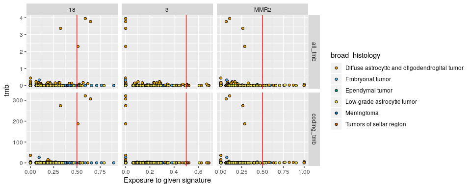

```r
sigs_of_interest <- c(3, 18,"MMR2")
tmb_sigs_df <- exposures %>%
  dplyr::select(signature, exposure, Kids_First_Biospecimen_ID, cancer_group_display, broad_histology) %>%
  dplyr::distinct() %>%
  dplyr::inner_join(tmb_data) %>%
  tidyr::gather(dplyr::contains("tmb"), key = "tmb_type", value = "tmb")
# plot TMB against exposure to those three signatures
# Note that we fill by *broad_histology* and not cancer_group because there will be insufficient colors
tmb_sigs_df %>%
  dplyr::filter(signature %in% sigs_of_interest) %>%
  ggplot2::ggplot() +
  ggplot2::aes(x = exposure, y = tmb, fill = broad_histology) +
  ggplot2::geom_point(shape = 21, color ="black") +
  # guiding line for majority of signature exposure, >=0.5
  ggplot2::geom_vline(xintercept = 0.5, color = "red") +
  # gives a warning because insufficient colors
  colorblindr::scale_fill_OkabeIto() +
  ggplot2::labs(x = "Exposure to given signature") +
  ggplot2::facet_grid(tmb_type ~ signature, scales = "free")
```

Do the hypermutators also show dysregulated TP53?

We define hypermutant samples as > 10 Mut/Mb, and ultrahypermutant samples as >100 Mut/Mb, from reference [Campbell et al., 2017](https://doi.org/10.1016/j.cell.2017.09.048).

The output below shows hypermutator samples and…

- their molecular subtypes (which implicitly gives the cancer group)
- this also gives the **TP53 status**
- their tumor descriptor
- their *coding* TMB
- their exposures to all signatures (with those of interest appearing first: 3, 18, MMR2)

```r
# This chunk should NOT run in CI.
if (!(params$is_ci == 1)) {

  hypermutator_df <- tmb_sigs_df %>%
    # filter to the hypermutators
    dplyr::filter(tmb_type == "coding_tmb",
                  tmb >= 10,
                  signature != "Other") %>%
    dplyr::select(-tmb_type) %>%
    # add in molecular subtype information, **which contains tp53 status** AND cancer group
    dplyr::inner_join(
      dplyr::select(meta, Kids_First_Biospecimen_ID, molecular_subtype, tumor_descriptor, composition)
    ) %>%
    tidyr::spread(signature, exposure) %>%
    # it's all coding so can remove type column, but a rename is helpful
    dplyr::rename(coding_tmb = tmb) %>%
    # order columns so sigs of interest come first
    dplyr::select(Kids_First_Biospecimen_ID, molecular_subtype, tumor_descriptor, composition, coding_tmb, sigs_of_interest, dplyr::everything()) %>%
    # we don't need cancer_group_display, the info is in molecular_subtype
    dplyr::select(-cancer_group_display) %>%
    # arrange in order of burden
    dplyr::arrange(-coding_tmb)

  hypermutator_df
}
```

| Kids_First_Biospecimen_ID | molecular_subtype | tumor_descriptor | composition | coding_tmb | 3 | 18 | MMR2 | broad_histology | 1 | 11 | 19 | 8 | N6 |
| --- | --- | --- | --- | --- | --- | --- | --- | --- | --- | --- | --- | --- | --- |
| BS_8AY2GM4G | HGG, H3 wildtype, TP53 loss | Progressive | Solid Tissue | 321.60795 | 0 | 0.58959674 | 0.10552573 | Diffuse astrocytic and oligodendroglial tumor | 0.06102105 | 0.17649902 | 0.06735745 | 0 | 0 |
| BS_20TBZG09 | HGG, H3 wildtype, TP53 loss | Initial CNS Tumor | Solid Tissue | 307.04922 | 0 | 0.64568547 | 0.06414602 | Diffuse astrocytic and oligodendroglial tumor | 0.06976048 | 0.16507593 | 0.00000000 | 0 | 0 |
| BS_02YBZSBY | HGG, H3 wildtype, TP53 activated | Progressive | Solid Tissue | 274.48806 | 0 | 0.32373868 | 0.26382938 | Diffuse astrocytic and oligodendroglial tumor | 0.25182593 | 0.08152533 | 0.07908069 | 0 | 0 |
| BS_VW4XN9Y7 | HGG, H3 wildtype, TP53 activated | Initial CNS Tumor | Solid Tissue | 187.38765 | 0 | 0.51099239 | 0.28619721 | Diffuse astrocytic and oligodendroglial tumor | 0.08372040 | 0.08217051 | 0.00000000 | 0 | 0 |
| BS_HM5GFJN8 | DMG, H3 K28, TP53 loss | Progressive | Derived Cell Line | 35.89287 | 0 | 0.00000000 | 0.00000000 | Diffuse astrocytic and oligodendroglial tumor | 0.00000000 | 0.78635612 | 0.14246632 | 0 | 0 |
| BS_F0GNWEJJ | NA | Progressive | Solid Tissue | 26.26171 | 0 | 0.09369152 | 0.07097621 | Embryonal tumor | 0.00000000 | 0.62242217 | 0.19348875 | 0 | 0 |
| BS_P3PF53V8 | HGG, H3 wildtype, TP53 activated | Initial CNS Tumor | Solid Tissue | 15.48265 | 0 | 0.18910506 | 0.00000000 | Diffuse astrocytic and oligodendroglial tumor | 0.74705992 | 0.00000000 | 0.00000000 | 0 | 0 |

A couple interesting observations in the table above:

- *No samples* are exposed to signature 3, 8, or N6.
- The DMG hypermutator sample (TMB=35.89) is mostly exposed to [signature 11](https://signal.mutationalsignatures.com/explore/referenceCancerSignature/40). This signature was thought to be associated with temozolomide, except that original evidence has not been reproduced.
- The HGG hypermutator sample with lowest TMB (TMB=15.48) is primarily exposed to signature 1, which is a normal signature.
- Six of the samples are HGG, and one is an embryonal tumor.

### Make heatmap for mutational signatures for patients with hypermutant tumors

```r
# This chunk should NOT run in CI.
if (!(params$is_ci == 1)) {


  # Create signature matrix for only patients withh hypermutant samples
  # Gather all BS_IDs (soi = "samples of interest"), whether hypermutant or not, for pts with hypermutant samples

  soi_df <- meta %>%
    filter(Kids_First_Biospecimen_ID %in% hypermutator_df$Kids_First_Biospecimen_ID) %>%
    select(Kids_First_Participant_ID) %>%
    left_join(meta) %>%
    #keep only WGS samples; remove normals; keep cell lines
    filter(experimental_strategy == "WGS" & !is.na(pathology_diagnosis)) %>%
    select(Kids_First_Participant_ID, Kids_First_Biospecimen_ID, tumor_descriptor, composition) %>%
    unique() %>%
    arrange(Kids_First_Participant_ID)

  sigs <- exposures %>%
    filter(signature != "Other") %>%
    tidyr::spread(signature, exposure) %>%
    select(-broad_histology, -n, -cancer_group_display, -cancer_group_hex, -tumor_descriptor) %>%
    filter(Kids_First_Biospecimen_ID %in% soi_df$Kids_First_Biospecimen_ID) %>%
    as.data.frame() %>%
    arrange(Kids_First_Biospecimen_ID) %>%
    write_tsv(sig_matrix_file)

  # add spaces at the end of BS_ids to make a space between the heatmap and legend
  rownames(sigs) <- paste0(sigs$Kids_First_Biospecimen_ID, "     ")

  sigs$Kids_First_Biospecimen_ID <- NULL
  sigs <- as.matrix(sigs)

  # Create annotation dataframe
  anno <- tmb_coding %>%
    mutate(Kids_First_Biospecimen_ID = Tumor_Sample_Barcode) %>%
    select(Kids_First_Biospecimen_ID, tmb) %>%
    # add a column for mutation status
    mutate(
      `Mutation status` = case_when(
        tmb < 10 ~ "Normal",
        tmb >= 10 & tmb < 100 ~ "Hypermutant",
        tmb >= 100 ~ "Ultra-hypermutant")
    ) %>%
    right_join(soi_df, by = "Kids_First_Biospecimen_ID") %>%
    unique() %>%
    # mutate names for annotation
    mutate(Patient = Kids_First_Participant_ID,
           `Phase of Therapy` = tumor_descriptor,
           Composition = composition) %>%
    select(Patient, Kids_First_Biospecimen_ID, `Phase of Therapy`, Composition, `Mutation status`) %>%
    as.data.frame() %>%
    arrange(Kids_First_Biospecimen_ID)

  # set rownames to match matrix, remove BS_ID
  rownames(anno) <- paste0(anno$Kids_First_Biospecimen_ID, "     ")
  anno$Kids_First_Biospecimen_ID <- NULL

  # Add tumor descriptor palette from dataframe
  td_palette_filtered <- td_palette %>%
    filter(color_names %in% anno$`Phase of Therapy`)
  td_palette_col <- as.character(td_palette_filtered$hex_codes)
  names(td_palette_col) <- td_palette_filtered$color_names

  pt_palette <- colorRampPalette(palette_OkabeIto)(length(unique(anno$Patient)))
  names(pt_palette) <- unique(anno$Patient)

  comp_palette <- as.character(bin_palette$hex_codes)
  names(comp_palette) <- unique(anno$Composition)

  # Specify colors
  ann_colors = list(
    # mutator color from [this PR](https://github.com/AlexsLemonade/OpenPBTA-analysis/pull/1280/files#diff-bc8134008706f38e7795b59696928058d123e44b4172df68105a26ad8aa0a398R298-R301)
    `Mutation status` = c(Normal = "grey40",
                          Hypermutant = "orange",
                          `Ultra-hypermutant` = "red"),
    Composition = comp_palette,
    `Phase of Therapy` = td_palette_col,
    Patient = pt_palette)

  # Heatmap annotation
  row_anno = rowAnnotation(df = anno,
                           col = ann_colors, show_legend=FALSE)

  # Make heatmap without legends
  heat_plot <- Heatmap(sigs[, c("1", "3", "8", "11", "18", "19", "MMR2", "N6")],
                       name = "Signature weights",
                       col = colorRampPalette(c("#f1f1f1", "#2166ac"))(50),
                       cluster_rows = FALSE,
                       show_row_names = TRUE,
                       show_heatmap_legend=FALSE,
                       cluster_columns = FALSE,
                       right_annotation = row_anno,
                       rect_gp = gpar(col = "white"),
                       row_split = anno$Patient,
                       row_title = NULL,
                       column_title = "RefSig Mutational Signature Weights",
                       column_title_side = "bottom")

  heat_plot

  # Make separate legends to compile in Illustrator
  patient_legend <- Legend(
    labels = names(ann_colors$Patient),
    legend_gp = gpar(fill = ann_colors$Patient),
    title = "Patient"
  )

  mutator_legend <- Legend(
    labels = names(ann_colors$`Mutation status`),
    legend_gp = gpar(fill = ann_colors$`Mutation status`),
    title = "Mutation status"
  )

  phase_legend <- Legend(
    labels = names(ann_colors$`Phase of Therapy`),
    legend_gp = gpar(fill = ann_colors$`Phase of Therapy`),
    title = "Phase of Therapy"
  )

  comp_legend <- Legend(
    labels = names(ann_colors$Composition),
    legend_gp = gpar(fill = ann_colors$Composition),
    title = "Composition"
  )

  weights_legend <- color_mapping_legend(heat_plot@matrix_color_mapping, plot = FALSE,
                                         legend_direction = "horizontal")

  heat_legends <- packLegend(patient_legend,
             mutator_legend,
             phase_legend,
             comp_legend,
             weights_legend,
             direction = "horizontal",
             column_gap = unit(0.75, "cm")
  )


  # save heatmap
  pdf(heatmap_file, width = 8, height = 4)
  print(heat_plot)
  dev.off()

  # save heatmap legends
  pdf(heatmap_legends_file, width = 8, height = 2)
  draw(heat_legends)
  dev.off()
 }
```

[output not shown]